# Take-Home Final Exam

Steve Harms

November 29, 2018

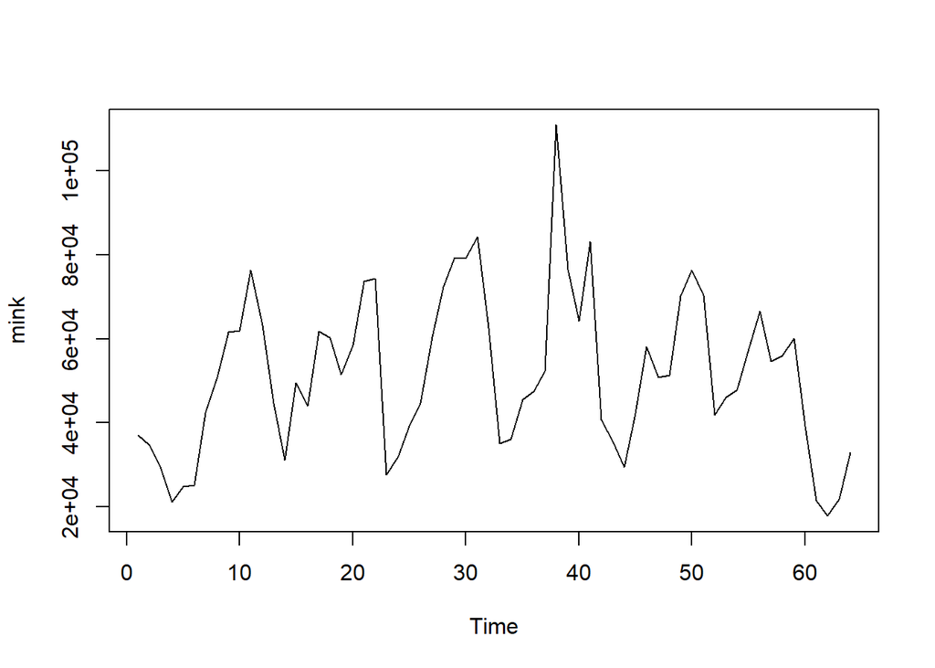

```r
library(itsmr)
#read in the data
mink <- ts(read.table("apph.tsm"))
#plot the original time series
ts.plot(mink)
```

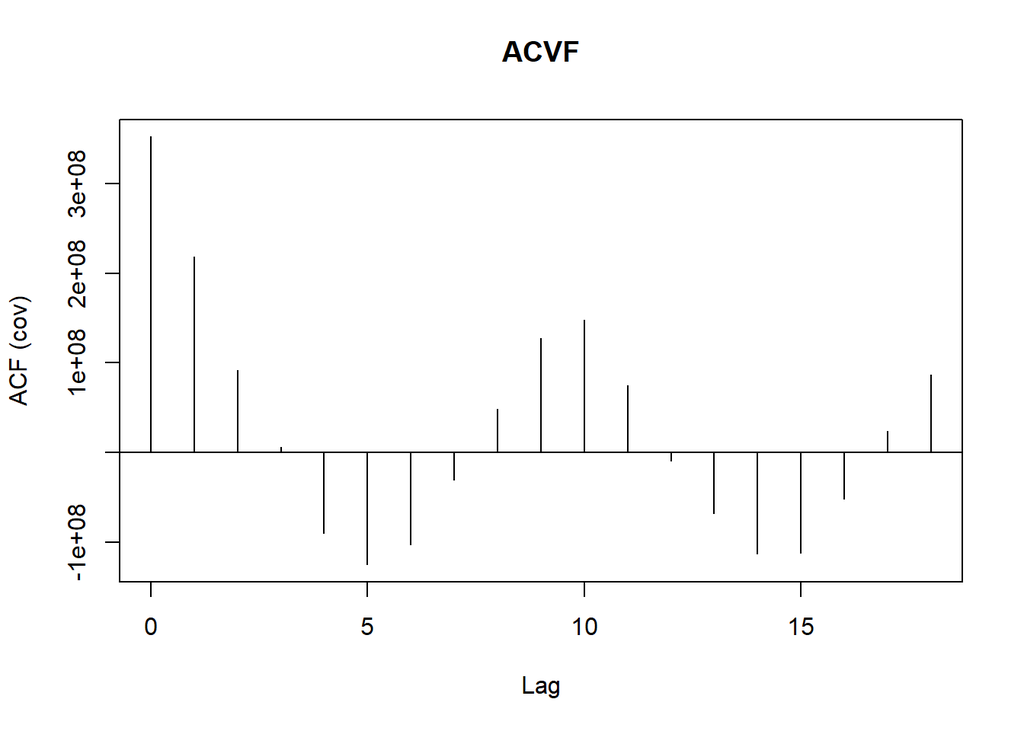

```r
#plot the ACVF, ACF and PACF
acf(mink, type="covariance", main = "ACVF")
```

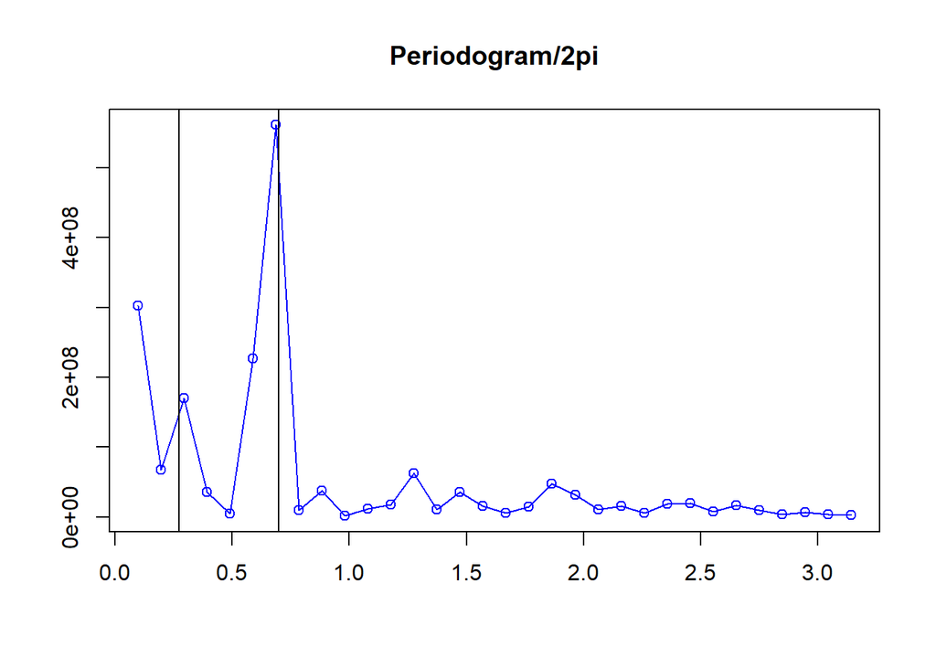

```
## numeric(0)
```

```r
#Plot the periodogram to examine the spectral density
periodogram(mink) + abline(v=2*pi/9)+ abline(v=2*pi/23)
```

*The periodogram indicates we have spikes at 2$\pi$/9 and 2$\pi$/23, indicating that periods of 9 and 23 might be our seasonal periods.*

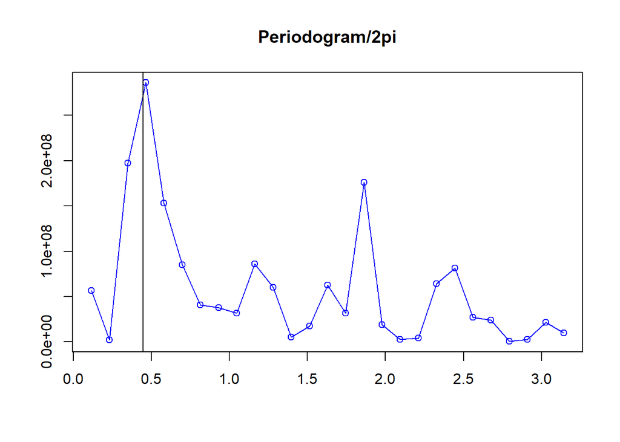

```
## numeric(0)
```

```r
#take seasonal differences with d=9
mink1 <- diff(mink,lag=9)
#plot the new periodogram
periodogram(mink1) + abline(v=2*pi/14)
```

*After taking seasonal difference operator d=9, the periodogram still indicates a spike at 2$\pi$/14, i.e., period = 14. This matches what we had above (9+14=23, the other spike in the original periodogram).*

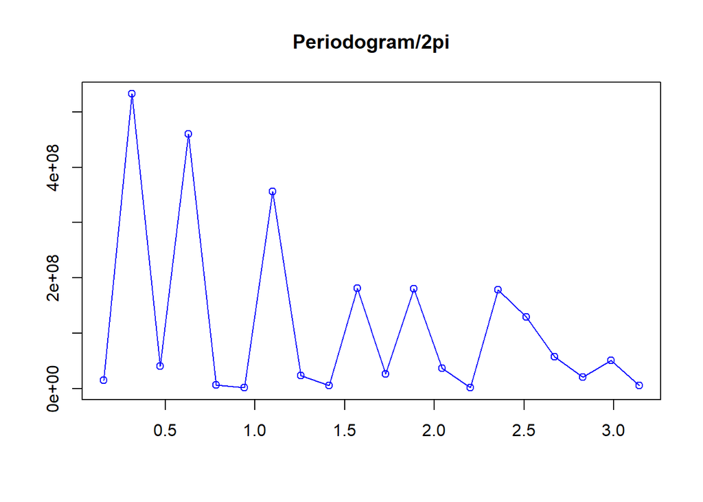

```r
#take another seasonal difference with d=9
mink14 <- diff(mink1, lag=14)
#periodogram
periodogram(mink14)
```

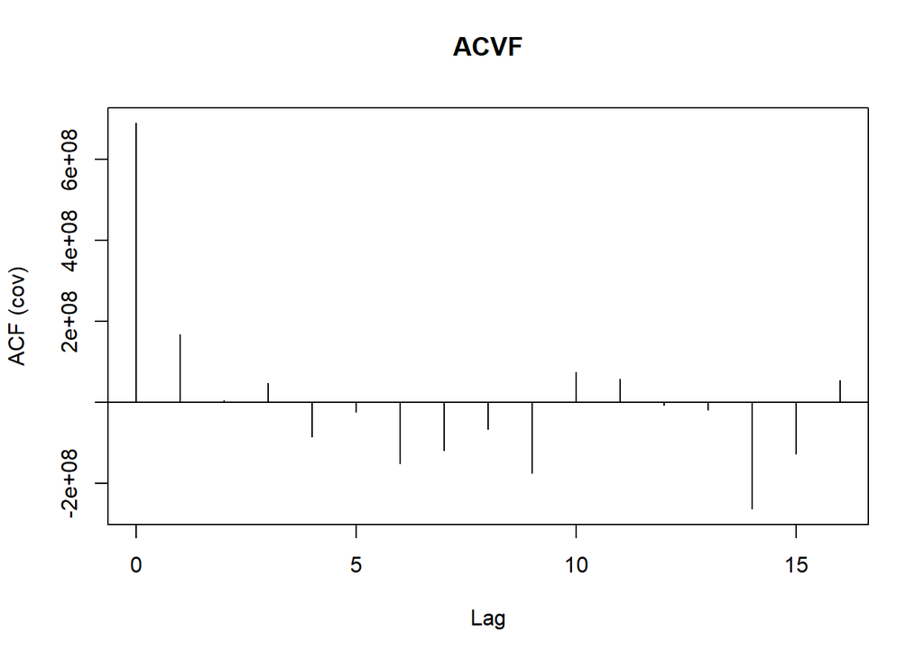

```r
#plot acvf and acf and pacf
acf(mink14,type="covariance", main="ACVF")
```

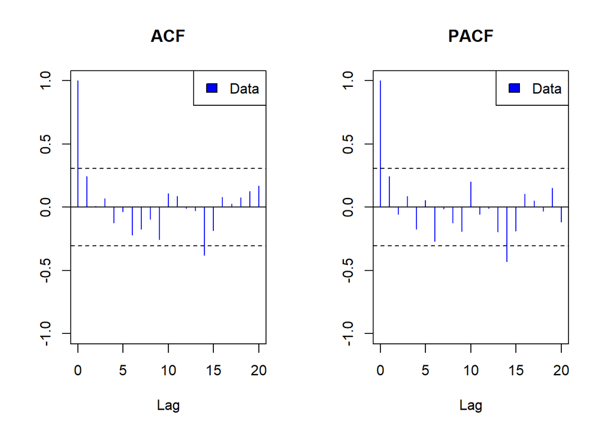

```r
plota(mink14, h=20)
```

*The new PACF indicates we may not need any AR terms in our final model after differencing. The ACF and ACVF look reasonable, so it’s time to look at possible ARMA models for the residuals.*

```r
#estimate some models
arma11 <- arma(mink14, p=1, q=1)
arma10 <- arma(mink14, p=1, q=0)
arma01<- arma(mink14, p=0, q=1)
arma00 <- arma(mink14, p=0, q=0)
arma11$aicc; arma10$aicc; arma01$aicc; arma00$aicc
```

```
## [1] 953.4456
```

```
## [1] 952.4718
```

```
## [1] 952.1898
```

```
## [1] 952.8331
```

*The best model is the ARMA(0,1) model based on AICC, however all of the models considered above hare very close and thus are competitive. Using any of them to forecast leads to very similar predicitions. The forecast is largely determined by the seasonal structure, not the small scale MA and AR terms. Below, we can see that even for the MA(1) model, the $\theta$ term is not significant at an $\alpha$ = 5% significance level.* **Estimates and Confidence Intervals**

```r
#we can use autofit() to have ITSM pick the best model for us based on AICC
#turns out to be ARMA(0,1)
bestmodel <- autofit(mink14, p=0:5, q=0:10)
```

**$\phi$**

```r
bestmodel$phi
```

```
## [1] 0
```

```r
c(bestmodel$phi - qnorm(.975)*bestmodel$se.phi, bestmodel$phi + qnorm(.975)*bestmodel$se.phi)
```

```
## [1] 0 0
```

**$\theta$**

```r
bestmodel$theta
```

```
## [1] 0.2894548
```

```r
c(bestmodel$theta - qnorm(.975)*bestmodel$se.theta, bestmodel$theta + qnorm(.975)*bestmodel$se.theta)
```

```
## [1] -0.04953699  0.62844662
```

**White Noise variance $\sigma^2$**

*The variance is quite large, indicating that we may have trouble forecasting with this model*

```r
bestmodel$sigma2
```

```
## [1] 641209828
```

**Checking for White Noise in the residuals**

*The p-values for the Ljung-Box and McLeod-Li tests are both large, indicating that we fail to reject the null hypothesis. Conclude that our residuals for this model are Gaussian white noise. Similar results for the other models considered above.*

```r
test(Resid(mink,M=c("diff",9,"diff",14), a=bestmodel))
```

```
## Null hypothesis: Residuals are iid noise.
## Test                        Distribution Statistic   p-value
## Ljung-Box Q                Q ~ chisq(20)     25.31    0.1899
## McLeod-Li Q                Q ~ chisq(20)      23.3    0.2741
## Turning points T     (T-26)/2.6 ~ N(0,1)        30    0.1297
## Diff signs S         (S-20)/1.9 ~ N(0,1)        20         1
## Rank P             (P-410)/44.5 ~ N(0,1)       425    0.7361
```

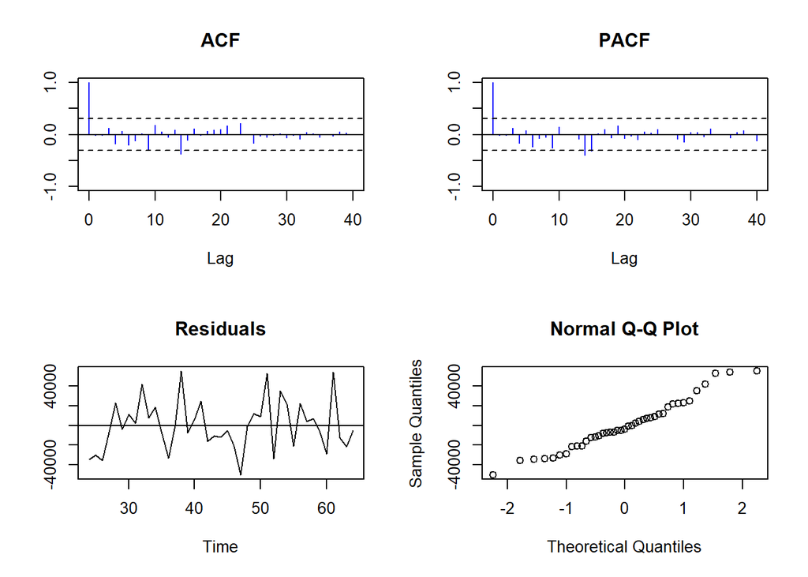

**Finally, a forecast of our model.**

```r
forecast(mink, M=c("diff",9,"diff",14), a=bestmodel, h=10)
```

```
##  Step     Prediction      sqrt(MSE)    Lower Bound    Upper Bound
##     1        88396.6       25322.12       38766.16         138027
##     2       54831.39       26361.58       3163.639       106499.1
##     3       66210.39       26361.58       14542.64       117878.1
##     4       59317.39       26361.58       7649.639       110985.1
##     5       32333.39       26361.58      -19334.36       84001.14
##     6       30983.39       26361.58      -20684.36       82651.14
##     7       14960.39       26361.58      -36707.36       66628.14
##     8        1270.39       26361.58      -50397.36       52938.14
##     9       10411.39       26361.58      -41256.36       62079.14
##    10       50873.99       36553.29      -20769.14       122517.1
```

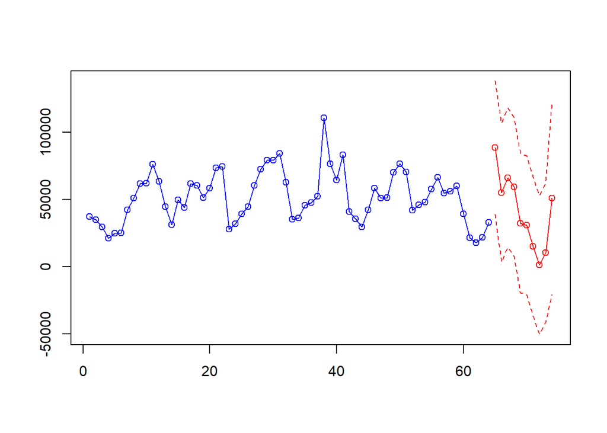

```r
forecast(mink, M=NULL, a=autofit(mink, p=0:5,q=0:10), h=10)
```

```
##  Step     Prediction      sqrt(MSE)    Lower Bound    Upper Bound
##     1        49920.2       12198.92       26010.77       73829.64
##     2       62369.07       13897.62       35130.24        89607.9
##     3       67733.93       14112.51       40073.93       95393.94
##     4       65903.47       14406.52        37667.2       94139.73
##     5       57928.43       14554.27       29402.59       86454.26
##     6       47482.01       14559.11       18946.68       76017.34
##     7        39175.5       14628.13        10504.9        67846.1
##     8       36528.22       14846.19       7430.214       65626.22
##     9        40483.1       15057.46       10971.02       69995.19
##    10       49090.97       15122.82        19450.8       78731.15
```

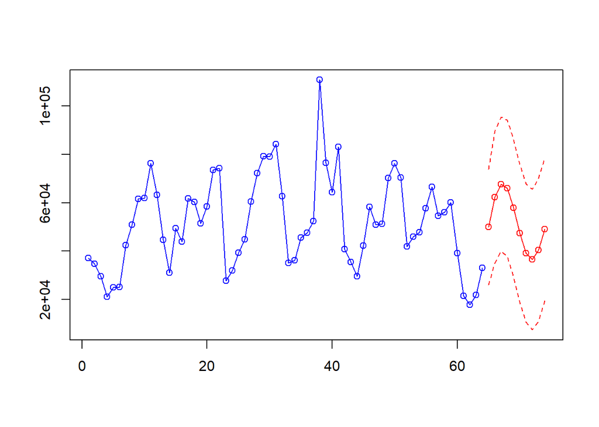